# Project Title: CRIME RATE ANALYSIS

## About the Dataset

### Dataset source: https://www.kaggle.com/datasets/marshallproject/crime-rates

## OBJECTIVES OF THE ANALYSIS

The dataset is wide but for the purpose of this project, we will keep the analysis simple and direct it to answer the following objective questions. The objectives of this analysis is to answer the following questions:

What has been the trend of crime rate reported in each agency jurisdiction? DId any agency jurisdiction experience any sudden hike in the rate of crime reported?

```python
#import libraries
import pandas as pd
import numpy as np
from matplotlib import pyplot as plt
```

```python
#load the dataset
df = pd.read_csv("C:\\Users\\User\\OneDrive\\Desktop\\My Projects\\Crime Analysis\\report.csv")
```

```python
#view the dataset
df.sample(5)
```

|  | report_year | agency_code | agency_jurisdiction | population | violent_crimes | homicides | rapes | assaults | robberies | months_reported | crimes_percapita | homicides_percapita | rapes_percapita | assaults_percapita | robberies_percapita |
| --- | --- | --- | --- | --- | --- | --- | --- | --- | --- | --- | --- | --- | --- | --- | --- |
| 1835 | 2001 | NY03030 | New York City, NY | 8023018.0 | 68173.0 | 629.0 | 1530.0 | 37812.0 | 28202.0 | 12.0 | 849.72 | 7.84 | 19.07 | 471.29 | 351.51 |
| 2258 | 2007 | OR02602 | Portland, OR | 538133.0 | 3701.0 | 22.0 | 280.0 | 2110.0 | 1289.0 | 12.0 | 687.75 | 4.09 | 52.03 | 392.10 | 239.53 |
| 2767 | 2015 | MA01301 | Boston, MA | 665258.0 | 4702.0 | 38.0 | 240.0 | 2873.0 | 1551.0 | NaN | 706.79 | 5.71 | 36.08 | 431.86 | 233.14 |
| 1018 | 1989 | NC09201 | Raleigh, NC | 189132.0 | 1248.0 | 15.0 | 102.0 | 751.0 | 380.0 | 12.0 | 659.86 | 7.93 | 53.93 | 397.08 | 200.92 |
| 718 | 1985 | CA01900 | Los Angeles County, CA | 1074561.0 | 10624.0 | 164.0 | 520.0 | 6118.0 | 3822.0 | 12.0 | 988.68 | 15.26 | 48.39 | 569.35 | 355.68 |

```python
#shape of the dataset
df.shape
```

```
(2829, 15)
```

## Data Cleaning

```python
#check for nan values
df.isna().sum()
```

```
report_year              0
agency_code             41
agency_jurisdiction      0
population              69
violent_crimes          35
homicides               34
rapes                   75
assaults                76
robberies               75
months_reported        137
crimes_percapita        35
homicides_percapita     34
rapes_percapita         75
assaults_percapita      76
robberies_percapita     75
dtype: int64
```

```python
#To check the percentage of missig values
missing_values = (2829 - 2688)/2829 * 100
missing_values
```

```
4.984093319194061
```

### Since the missing values is less than 10% of the entire dataset, we decided to drop the rows containing the missing values.

```python
#drop rows containing nan values
df.dropna(inplace = True)
```

```python
df.shape
```

```
(2688, 15)
```

```python
#confirm if the Nan values have been removed
df.isna().sum()
```

```
report_year            0
agency_code            0
agency_jurisdiction    0
population             0
violent_crimes         0
homicides              0
rapes                  0
assaults               0
robberies              0
months_reported        0
crimes_percapita       0
homicides_percapita    0
rapes_percapita        0
assaults_percapita     0
robberies_percapita    0
dtype: int64
```

```python
#check for duplicate values
df.duplicated().sum()
```

```
0
```

### There are no dupilicate values in our dataset

```python
df.dtypes
```

[output not shown]

```python
df.info()
```

```
<class 'pandas.core.frame.DataFrame'>
Index: 2688 entries, 0 to 2758
Data columns (total 15 columns):
 #   Column               Non-Null Count  Dtype
---  ------               --------------  -----
 0   report_year          2688 non-null   object
 1   agency_code          2688 non-null   object
 2   agency_jurisdiction  2688 non-null   object
 3   population           2688 non-null   float64
 4   violent_crimes       2688 non-null   float64
 5   homicides            2688 non-null   float64
 6   rapes                2688 non-null   float64
 7   assaults             2688 non-null   float64
 8   robberies            2688 non-null   float64
 9   months_reported      2688 non-null   float64
 10  crimes_percapita     2688 non-null   float64
 11  homicides_percapita  2688 non-null   float64
 12  rapes_percapita      2688 non-null   float64
 13  assaults_percapita   2688 non-null   float64
 14  robberies_percapita  2688 non-null   float64
dtypes: float64(12), object(3)
memory usage: 336.0+ KB
```

```python
df.describe()
```

|  | population | violent_crimes | homicides | rapes | assaults | robberies | months_reported | crimes_percapita | homicides_percapita | rapes_percapita | assaults_percapita | robberies_percapita |
| --- | --- | --- | --- | --- | --- | --- | --- | --- | --- | --- | --- | --- |
| count | 2.688000e+03 | 2688.000000 | 2688.000000 | 2688.000000 | 2688.000000 | 2688.000000 | 2688.000000 | 2688.000000 | 2688.000000 | 2688.000000 | 2688.000000 | 2688.000000 |
| mean | 7.931257e+05 | 9004.445312 | 125.644345 | 415.340774 | 4422.396949 | 4041.063244 | 11.886533 | 1109.191146 | 15.559691 | 59.404862 | 569.724241 | 464.502448 |
| std | 1.010316e+06 | 16007.228845 | 205.001170 | 480.924802 | 7028.064975 | 8744.855463 | 1.020882 | 681.687782 | 12.399596 | 32.053618 | 371.365208 | 342.713406 |
| min | 1.007630e+05 | 154.000000 | 1.000000 | 15.000000 | 15.000000 | 83.000000 | 0.000000 | 16.490000 | 0.210000 | 1.640000 | 1.610000 | 11.460000 |
| 25% | 3.771285e+05 | 2973.250000 | 32.000000 | 176.000000 | 1464.250000 | 1035.000000 | 12.000000 | 638.100000 | 7.077500 | 35.835000 | 320.242500 | 213.507500 |
| 50% | 5.341290e+05 | 5088.500000 | 63.000000 | 289.000000 | 2598.000000 | 1964.000000 | 12.000000 | 968.890000 | 12.315000 | 55.965000 | 490.980000 | 378.880000 |
| 75% | 8.119650e+05 | 8829.250000 | 127.250000 | 464.000000 | 4568.000000 | 3649.250000 | 12.000000 | 1427.115000 | 20.462500 | 77.807500 | 730.195000 | 617.112500 |
| max | 8.473938e+06 | 174542.000000 | 2245.000000 | 3899.000000 | 71030.000000 | 107475.000000 | 12.000000 | 4352.830000 | 94.740000 | 199.300000 | 2368.220000 | 2337.520000 |

There seems to be outliers in the dataset. For the homicides, rapes, assaults, robberies, and population columns, there seems to be a huge difference between the 75th percentile and the maximum. This signifies the presence of outliers. Let's take a better look at the outlier by considering a box plot.

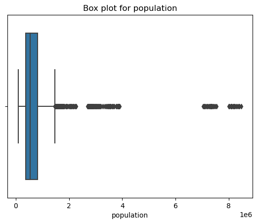

```python
#To find outliers in population
import seaborn as sns
sns.boxplot(x = df["population"])
plt.title("Box plot for population")
plt.xlabel("population")
plt.show()
```

```python
#confirm if the maximum population is a valid dataset
max_pop = df["population"].max()
max_pop
```

```
8473938.0
```

```python
#to check the agency_jurisdition of the maximum population
df[df["population"] == max_pop]
```

|  | report_year | agency_code | agency_jurisdiction | population | violent_crimes | homicides | rapes | assaults | robberies | months_reported | crimes_percapita | homicides_percapita | rapes_percapita | assaults_percapita | robberies_percapita |
| --- | --- | --- | --- | --- | --- | --- | --- | --- | --- | --- | --- | --- | --- | --- | --- |
| 2732 | 2014 | NY03030 | New York City, NY | 8473938.0 | 50564.0 | 333.0 | 2190.0 | 31460.0 | 16581.0 | 12.0 | 596.7 | 3.93 | 25.84 | 371.26 | 195.67 |

The maximum population represents the population of New York City in the year 2014. The population is correct so the outliers for the population column seems to be a valid dataset

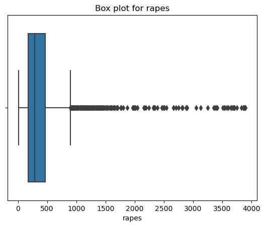

```python
#let's consider the outliers in the rapes column
sns.boxplot(x = df["rapes"])
plt.title("Box plot for rapes")
plt.xlabel("rapes")
plt.show()
```

```python
#confirm if the maximum rape cases reported is a valid dataset
max_rape = df["rapes"].max()
max_rape
```

```
3899.0
```

```python
df[df["rapes"] == max_rape]
```

|  | report_year | agency_code | agency_jurisdiction | population | violent_crimes | homicides | rapes | assaults | robberies | months_reported | crimes_percapita | homicides_percapita | rapes_percapita | assaults_percapita | robberies_percapita |
| --- | --- | --- | --- | --- | --- | --- | --- | --- | --- | --- | --- | --- | --- | --- | --- |
| 179 | 1977 | NY03030 | New York City, NY | 7481613.0 | 121916.0 | 1557.0 | 3899.0 | 42056.0 | 74404.0 | 12.0 | 1629.54 | 20.81 | 52.11 | 562.12 | 994.49 |

The maximum rapes represents the number of reported cases of rape in New York City in the year 1977. The number of rapes is correct so the outliers for the rapes column are valid dataset

## Data Visualization

```python
#To checck the unique values for the agency_jurisdiction
df["agency_jurisdiction"].unique().sum()
```

```
"Albuquerque, NMArlington, TXAtlanta, GAAurora, COAustin, TXBaltimore County, MDBaltimore, MDBoston, MABuffalo, NYCharlotte, NCChicago, ILCincinnati, OHCleveland, OHColumbus, OHDallas, TXDenver, CODetroit, MIEl Paso, TXFairfax County, VAFort Worth, TXFresno, CAHonolulu, HIHouston, TXIndianapolis, IN…
```

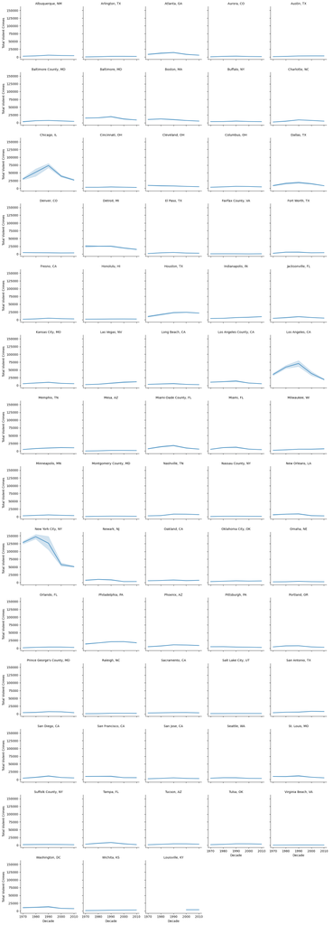

```python
#Since we have about 70 different agency_jurisdictions, the best plot is to separate each of the different jurisdiction
import seaborn as sns


df["report_year"] = df["report_year"].astype(int)

# Calculate the decade
df['decade'] = (df['report_year'] // 10) * 10

# Create a FacetGrid
g = sns.FacetGrid(df, col='agency_jurisdiction', col_wrap=5, height=3)
g.map(sns.lineplot, 'decade', 'violent_crimes')

# Customize the appearance
g.set_axis_labels('Decade', 'Total Violent Crimes')
g.set_titles('{col_name}')
g.add_legend()

plt.show()
```

## Insight

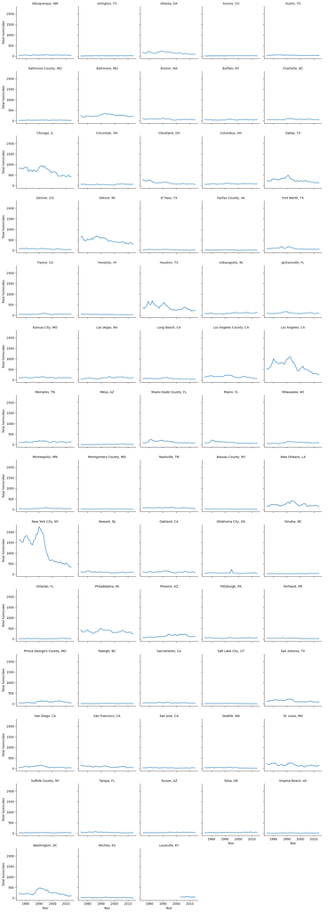

```python
# Create a FacetGrid
g = sns.FacetGrid(df, col='agency_jurisdiction', col_wrap=5, height=3)
g.map(sns.lineplot, 'report_year', 'homicides')

# Customize the appearance
g.set_axis_labels('Year', 'Total homicides')
g.set_titles('{col_name}')
g.add_legend()

plt.show()
```

## Insight

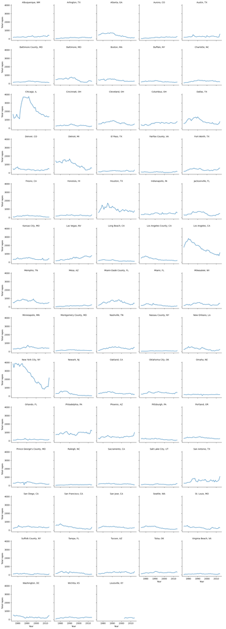

```python
# Create a FacetGrid
g = sns.FacetGrid(df, col='agency_jurisdiction', col_wrap=5, height=3)
g.map(sns.lineplot, 'report_year', 'rapes')

# Customize the appearance
g.set_axis_labels('Year', 'Total rapes')
g.set_titles('{col_name}')
g.add_legend()

plt.show()
```

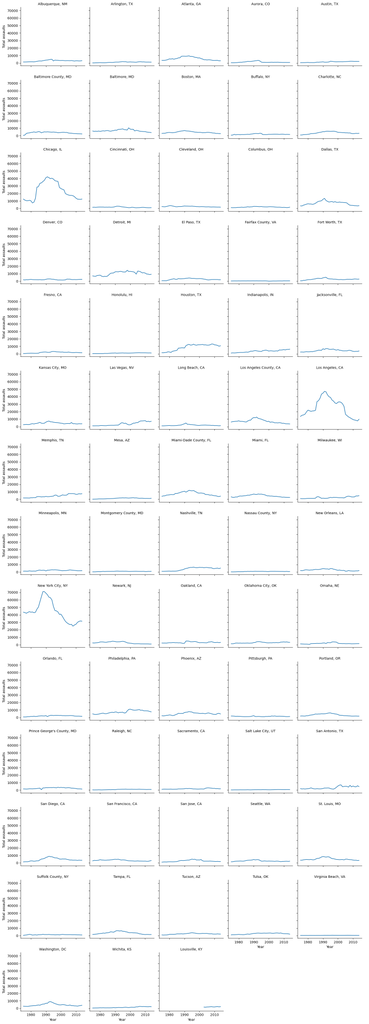

```python
# Create a FacetGrid
g = sns.FacetGrid(df, col='agency_jurisdiction', col_wrap=5, height=3)
g.map(sns.lineplot, 'report_year', 'assaults')

# Customize the appearance
g.set_axis_labels('Year', 'Total assaults')
g.set_titles('{col_name}')
g.add_legend()

plt.show()
```

## Insight

- Chicago, IL , Los Angeles, CA both experienced an increase assaults cases reported from 1980 to 1990 after which they experienced decrease from 1990 to 2010.
- New York City, NY experienced a huge decrease in assaults cases reported after a little hike from 1970 to 1990. Worthy of note, assault cases reported in New York City, NY is begining to rise.
- All other jurisdictions show little or no change in the rate of assault cases reported

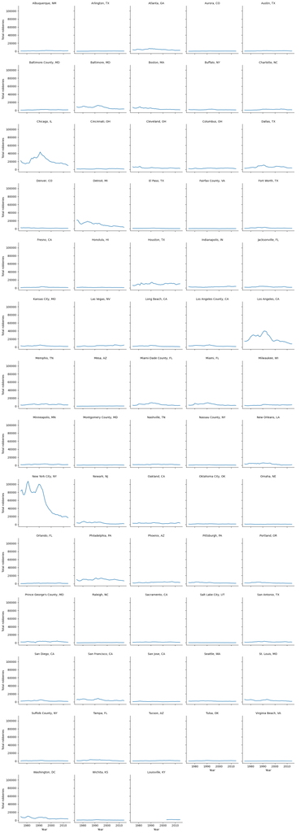

```python
# Create a FacetGrid
g = sns.FacetGrid(df, col='agency_jurisdiction', col_wrap=5, height=3)
g.map(sns.lineplot, 'report_year', 'robberies')

# Customize the appearance
g.set_axis_labels('Year', 'Total robberies')
g.set_titles('{col_name}')
g.add_legend()

plt.show()
```

## Insight

- Chicago, IL , Los Angeles, CA both experienced an increase robbery cases reported from 1970 to 1990 after which they experienced decrease from 1990 to 2010.
- New York City, NY experienced a huge decrease in robbery cases reported after a little hike from 1970 to 1990.
- All other jurisdictions show little or no change in the rate of robbery cases reported

## Conclusion

- Crime started rising around 1960 in the New York City for unknown reasons. Crime started decreasing in 1991, due to a new mayor and his 'get tough’ policing policies.
- In California, there was a lot of competition for the crack market from the late 1980s to the 1990s in the inner city community, and that led to a large numberof homicide and other vices.